# Study A: Exploring scRNA-seq data from 5 cancer cell lines with scBubbletree

### quality control with `scBubbletree`

What is the percent of UMIs coming from mitochondrial genes in each bubble?

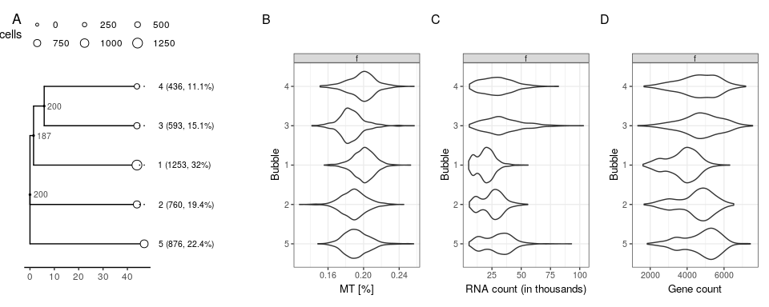

```r
w_mt_dist <- get_num_violins(btd = k5_kmeans,
                             fs = 1-d@meta.data$non_mt_percent,
                             x_axis_name = 'MT [%]',
                             rotate_x_axis_labels = T)

w_umi_dist <- get_num_violins(btd = k5_kmeans,
                              fs = d@meta.data$nCount_RNA/1000,
                              x_axis_name = 'RNA count (in thousands)',
                              rotate_x_axis_labels = T)

w_gene_dist <- get_num_violins(btd = k5_kmeans,
                               fs = d@meta.data$nFeature_RNA,
                               x_axis_name = 'Gene count',
                               rotate_x_axis_labels = T)


(k5_kmeans$tree|w_mt_dist$plot|w_umi_dist$plot|w_gene_dist$plot)+
  patchwork::plot_layout(widths = c(1, 1, 1, 1))+
  patchwork::plot_annotation(tag_levels = 'A')
```

### Are H1975 and HCC827 transcriptionally similar?

To check this we will use gene expression data for 69 lung adenocarcinoma cell lines from the Cancer Cell Line Encyclopedia[^3]. Lets check if H1975 and HCC827 have similar gene expression profiles based on this data as well.

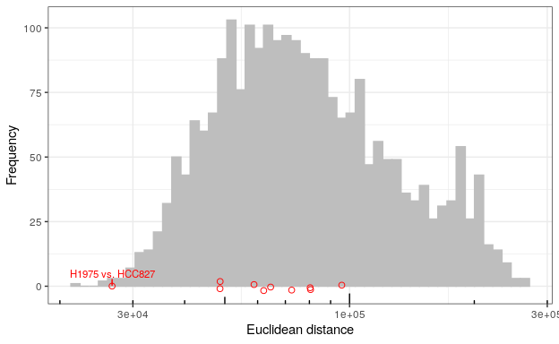

## UMAP and t-SNE

Generating 2D UMAP and t-SNE plots is a standard first step in scRNA-seq data analysis. Lets do this now:

```r
umap_data <- cbind(d@meta.data, d@reductions$umap@cell.embeddings)
umap_data$closest_cluster <- NA
umap_centers <- merge(x = aggregate(UMAP_1~cell_line_demuxlet,
                                    data = umap_data, FUN = median),
                      y = aggregate(UMAP_2~cell_line_demuxlet,
                                    data = umap_data, FUN = median),
                      by = "cell_line_demuxlet")


tsne_data <- cbind(d@meta.data, d@reductions$tsne@cell.embeddings)
tsne_data$closest_cluster <- NA
tsne_centers <- merge(x = aggregate(tSNE_1~cell_line_demuxlet,
                                    data = tsne_data, FUN = median),
                      y = aggregate(tSNE_2~cell_line_demuxlet,
                                    data = tsne_data, FUN = median),
                      by = "cell_line_demuxlet")
```

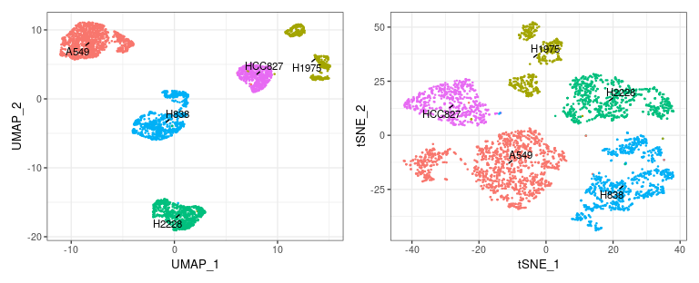

```r
g_umap_tsne <- ggplot()+
  geom_point(data = umap_data,
             aes(x = UMAP_1, y = UMAP_2, col = cell_line_demuxlet), size = 0.25)+
  geom_text_repel(data = umap_centers,
            aes(x = UMAP_1, y = UMAP_2, label = cell_line_demuxlet),
            min.segment.length = 0, size = 3)+
  theme(legend.position = "none")+
  guides(colour = guide_legend(nrow = 4,
                               override.aes = list(size=2)))|
  ggplot()+
  geom_point(data = tsne_data,
             aes(x = tSNE_1, y = tSNE_2, col = cell_line_demuxlet), size = 0.25)+
  geom_text_repel(data = tsne_centers,
            aes(x = tSNE_1, y = tSNE_2, label = cell_line_demuxlet),
            min.segment.length = 0, size = 3)+
  theme(legend.position = "none")+
  guides(colour = guide_legend(nrow = 4,
                               override.aes = list(size=2)))

g_umap_tsne
```

The clustering of both algorithms seems to work well, i.e. cells from specific cell lines are clustered together. Two potential issues:

1. overplotting: points are stacked on top of each other $\rightarrow$ loss of information about cell density distribution $\rightarrow$ we are unable to accurately answer two questions:
   - which cell line contains most cells?
   - what are the relative frequencies of cells across cell lines?
2. preservation of long-range cell distances: UMAP and t-SNE focus on preserving local cell distance (at the cost of global distances) $\rightarrow$ are there pairs of cell lines that are more similar to each other than the remaining ones in the sample?

These challenges will become more severe in real datasets (e.g. PBMC samples, see case study B) which contain many clusters of cells that are not clearly separable.

## Are local/global distances between cells preserved by UMAP/t-SNE?

Local cell distances appear to be adequately recovered, long-range distances are not. Gray points are intra-bubble distances and black points are inter-bubble distances.

```r
get_euc_dist <- function(x, pairs, m) {

  get_euc <- function(x, y) {
    return(sqrt(sum((x-y)^2)))
  }

  i <- pairs[x,1]
  j <- pairs[x,2]

  return(sqrt(sum((m[i,]-m[j,])^2)))
}


pairs <- t(replicate(n = 5*10^4, sample(x = 1:nrow(A), size = 2)))

i_cell <- d@meta.data$cell_line_demuxlet[pairs[, 1]]
j_cell <- d@meta.data$cell_line_demuxlet[pairs[, 2]]
comparison <- ifelse(test = i_cell==j_cell, yes = "w", no = "b")
```

```r
euc_a <- lapply(X = 1:nrow(pairs), pairs = pairs,
                m = A, FUN = get_euc_dist)

euc_u <- lapply(X = 1:nrow(pairs), pairs = pairs,
                m = umap_data[, c("UMAP_1", "UMAP_2")],
                FUN = get_euc_dist)

euc_t <- lapply(X = 1:nrow(pairs), pairs = pairs,
                m = tsne_data[, c("tSNE_1", "tSNE_2")],
                FUN = get_euc_dist)

euc_x <- lapply(X = 1:nrow(pairs), pairs = pairs,
                m = t(as.matrix(d@assays$SCT@data)),
                FUN = get_euc_dist)


dist_preservation <- data.frame(euc_a = unlist(euc_a),
                                euc_u = unlist(euc_u),
                                euc_t = unlist(euc_t),
                                euc_x = unlist(euc_x),
                                i = i_cell,
                                j = j_cell,
                                comparison = comparison)
```

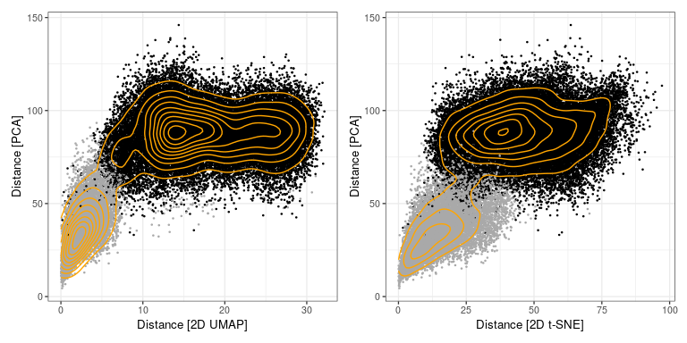

```r
g_pairs_umap_tsne <- ggplot(data = dist_preservation)+
  geom_point(aes(y = euc_a, x = euc_u, col = comparison), size = 0.25)+
  geom_density_2d(aes(y = euc_a, x = euc_u), col = "orange")+
  ylab(label = "Distance [PCA]")+
  xlab(label = "Distance [2D UMAP]")+
  scale_color_manual(values = c("black", "darkgray"))+
  theme(legend.position = "none")|
ggplot(data = dist_preservation)+
  geom_point(aes(y = euc_a, x = euc_t, col = comparison), size = 0.25)+
  geom_density_2d(aes(y = euc_a, x = euc_t), col = "orange")+
  ylab(label = "Distance [PCA]")+
  xlab(label = "Distance [2D t-SNE]")+
  scale_color_manual(values = c("black", "darkgray"))+
  theme(legend.position = "none")

g_pairs_umap_tsne
```

### scBubbletree can incorporate results from other clustering approaches

Wide range of clustering approaches are used for clustering of scRNA-seq data. `scBubbletree` implements the function `get_bubbletree_dummy` to allow users to incorporate results from various clustering approaches together with our workflow. With this function we skip the k-means clustering portion of the workflow and proceed with computing distances between the clusters and generation of the bubbletree.

Lets try `get_bubbletree_dummy`. First, will perform k-medoids clustering with R-package pam and then generate the bubbletree:

```r
pam_k5 <- cluster::pam(x = A,
                       k = 5,
                       metric = "euclidean")

dummy_k5_pam <- get_bubbletree_dummy(x = A,
                                     cs = pam_k5$clustering,
                                     B = 200,
                                     N_eff = 200,
                                     cores = 2,
                                     round_digits = 1)
```

```
FALSE Generating bubbletree ...
```

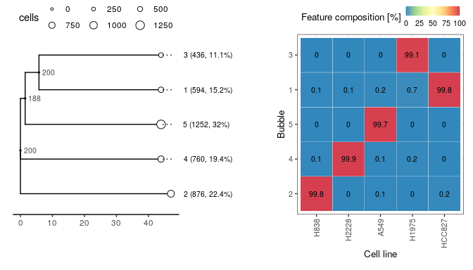

```r
dummy_k5_pam$tree|
  get_cat_tiles(btd = dummy_k5_pam,
                f = d@meta.data$cell_line_demuxlet,
                integrate_vertical = T,
                round_digits = 1,
                show_hclust = F,
                disable_hclust = F,
                tile_text_size = 2.75,
                x_axis_name = 'Cell line',
                rotate_x_axis_labels = T)$plot
```

### Summary

`scBubbletree` promotes simple and transparent visual exploration of scRNA-seq. It is *not a black-box* approach and the user *is encouraged* to explore the data with different values of $k$ and $r$ or custom clustering solutions. Attaching of cell features to the bubbletree is necessary for biological interpretation of the individual bubbles and their relationships which are described by the bubbletree topology.

[^1]: Tian, Luyi, et al. “Benchmarking single cell RNA-sequencing analysis pipelines using mixture control experiments.” Nature methods 16.6 (2019): 479-487.
[^2]: https://github.com/LuyiTian/sc_mixology/blob/master/data/sincell_with_class_5cl.RData
[^3]: https://www.ebi.ac.uk/gxa/experiments/E-MTAB-2770/Results